# 第二章 R语言数据操作

中国人民大学 统计学院  
周静

# 目录

- R中的数据类型
  - 数值型(numeric)
  - 字符型(character)
  - 逻辑型(logical)
  - 因子型(factor)
  - 时间型(Date/POSIXct/POSIXlt)
- R中的数据结构
  - 向量(vector)
  - 矩阵(matrix)
  - 数据框(dataframe)
  - 列表(list)
- 数据读入
  - 结构化数据读入
  - 非结构化数据读入

# 热门电影数据集简介：数据来源

[figure not shown]

# 热门电影数据集简介

- 数据变量说明

[figure not shown]

- 数据示例

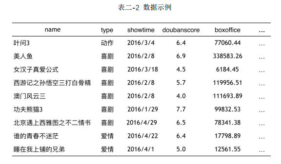

# 热门电影数据集简介：数据读入

- 把数据集读入R时，会以数据框（dataframe）的形式存储

```r
movie <- read.csv("电影数据.csv",header = T)       #读入电影数据
head(movie)                                        #查看数据前六行
##                       name boxoffice doubanscore type duration  showtime
## 1                    叶问3  77060.44         6.4 动作      105  2016/3/4
## 2                   美人鱼 338583.26         6.9 喜剧       93  2016/2/8
## 3           女汉子真爱公式   6184.45         4.5 喜剧       93 2016/3/18
## 4 西游记之孙悟空三打白骨精 119956.51         5.7 喜剧      120  2016/2/8
## 5               澳门风云三 111693.89         4.0 喜剧      112  2016/2/8
## 6                功夫熊猫3  99832.53         7.7 喜剧       95 2016/1/29
##   director      star1 index1        star2 index2
## 1   叶伟信     甄子丹  11385         张晋   4105
## 2   周星驰       邓超  41310         林允   9292
## 3   郭大雷     赵丽颖 181979         张翰  44277
## 4   郑保瑞     郭富城  12227         巩俐   8546
## 5     王晶     周润发  16731       刘德华  30277
## 6   吕寅荣 杰克布莱克    178 安吉丽娜朱莉   1540
```

# 基本数据类型：数值型

- 统计课本中的定量数据就是R中的数值类型,比如数据集中的doubanscore、boxoffice等就是这类数据。
- 通常，当你用符号“<-” 或者“=” 给一个变量赋予数字时，就默认生成数值型数据。

```r
#电影数据示例
class(movie$"boxoffice");class(movie$doubanscore)
## [1] "numeric"
## [1] "numeric"

#自己为变量赋一个数值
a <- 2;class(a)#数据对象的数据类型
## [1] "numeric"
```

- 下面几个命令会输出什么结果？

```r
exp(1000)
-10/0
exp(1000)/exp(990)
exp(10)
```

# 基本数据类型：字符型

- 储存文字？
- 用单引号或双引号定义（英文格式的引号）
- 大多数情况下，我们看到的文字就是字符类型，但是当一串文字被放在一个数据框（可先理解为一个数据表）中读进 R 时，极易被自动转换为因子型数据。

```r
#字符的定义
a <-"2"
class(a)
## [1] "character"
a <- "one"
class(a)
## [1] "character"

#判断电影数据集中，变量“type","name"是不是字符型变量
class(movie$type)
## [1] "factor"
class(movie$name)
## [1] "factor"
```

# 基本数据类型：逻辑型

- 取值有限，只有TRUE和FALSE两个值
- 常出现在各种条件设定语句中，比如if条件语句中
- 可进行加减运算，TRUE对应数字1，FALSE对应数字0

```r
#逻辑语句加减
1==2
## [1] FALSE
3<4
## [1] TRUE
(1==2)+(3<4)
## [1] 1
#读入数据时设置把字符数据保留，不转换为factor
movie <- read.csv("电影数据.csv",header = T,stringsAsFactors = F)
#判断《美人鱼》这部电影是否是喜剧
movie$type[movie$name=="美人鱼"]=="喜剧"
## [1] TRUE
#展示数据集中大于7分的喜剧电影的名字
movie$name[movie$type=="喜剧"& movie$"doubanscore">7]
## [1] "功夫熊猫3"
```

# 基本数据类型：因子型

- 通常可用命令 factor()来定义
- 可以储存有序型变量(带有顺序的名义型变量)

```r
genders<- factor(c("男","女","女","男","男"))
genders
## [1] 男 女 女 男 男
## Levels: 男 女
class<-factor(c("Poor","Improved","Excellent"),ordered = T)
class
## [1] Poor      Improved  Excellent
## Levels: Excellent < Improved < Poor
```

- 如何改变因子型数据各水平的编码顺序

```r
class<-factor(c("Poor","Improved","Excellent"),ordered = T,
              levels=c("Poor","Improved","Excellent"))
class
## [1] Poor      Improved  Excellent
## Levels: Poor < Improved < Excellent
```

- as.函数用于转换；is.函数用于查看类型

```r
#输入原始字符变量
all<-c("男","女","女","男","男")
#将字符型变量变成因子型
gender<-as.factor(all)
#变换后的数据类型
is.factor(gender)
## [1] TRUE
class(gender)
## [1] "factor"
#将因子型变量变成字符型
genders<-as.character(gender)
#变换后的数据类型
is.character(genders)
## [1] TRUE
class(genders)
## [1] "character"
```

# 基本数据类型：时间类

- Date日期数据，不包括时间和地区信息；
- POSIXct/POSIXlt类型数据，其实就是精确到秒级的时间戳。包括日期、时间时区信息

```r
## Date类型数据
mydate1 = as.Date(c("2017-10-23","2019-03-16"))
## POSIXct/POSIXlt类型数据
mydate2 = as.POSIXct(c("2017-10-23","2019-03-16"))
```

- 如何把字符转化成Date日期格式
- 默认转换斜杠（2017/10/23）或短线形式（2017-10-23）

```r
#函数head用来查看数据前6个元素,函数class用来查看对象数据类型
head(movie$showtime)
## [1] "2016/3/4"  "2016/2/8"  "2016/3/18" "2016/2/8"  "2016/2/8"  "2016/1/29"
class(movie$showtime)
## [1] "character"
movie$showtime<-as.Date(movie$showtime)
head(movie$showtime)
## [1] "2016-03-04" "2016-02-08" "2016-03-18" "2016-02-08" "2016-02-08"
## [6] "2016-01-29"
class(movie$showtime)
## [1] "Date"
#参数format对应错了有什么后果
Sys.setlocale("LC_TIME", "C")  # set local system default utf-8
## [1] "C"
x <- c("1jan1960", "2jan1960", "31mar1960", "30jul1960")
#y <- as.Date(x)
y <- as.Date(x,format="%d%b%Y");y
## [1] "1960-01-01" "1960-01-02" "1960-03-31" "1960-07-30"
```

- 日期格式示意表

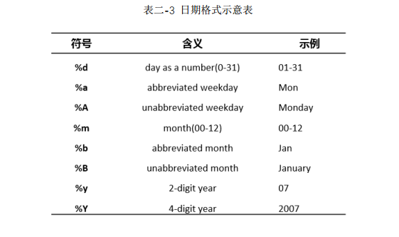

- 如何把字符转化成POSIXct/POSIXlt时间格式
- 默认转换格式为2017/10/23 01:34:56或2017-10-23 01:34:56

```r
as.POSIXct("2015-11-27 01:30:00")
## [1] "2015-11-27 01:30:00 CST"
#as.POSIXct("November-27-2015 01:30:00")
as.POSIXct("November-27-2015 01:30:00",format="%B-%d-%Y %H:%M:%S")
## [1] "2015-11-27 01:30:00 CST"
```

- strptime()也可以用于将字符串转换成时间格式，请自学之。
- 如何把时间数据摆弄成你想要的形式

```r
(m=head(movie$showtime)) #原始日期数据
## [1] "2016-03-04" "2016-02-08" "2016-03-18" "2016-02-08" "2016-02-08"
## [6] "2016-01-29"
format(m,format="%B %d %Y") #改成月日年的格式
## [1] "March 04 2016"    "February 08 2016" "March 18 2016"    "February 08 2016"
## [5] "February 08 2016" "January 29 2016"
format(m,format="%B %d %Y %A") #加入星期信息
## [1] "March 04 2016 Friday"    "February 08 2016 Monday"
## [3] "March 18 2016 Friday"    "February 08 2016 Monday"
## [5] "February 08 2016 Monday" "January 29 2016 Friday"
format(m,format="%B") #只提取出月份信息
## [1] "March"    "February" "March"    "February" "February" "January"
Sys.time()#输出系统时间
## [1] "2020-09-22 09:10:01 CST"
class(Sys.time())#查看时间类型
## [1] "POSIXct" "POSIXt"
format(Sys.time(),format = "%B %d %Y")#提取部分时间信息
## [1] "September 22 2020"
format(Sys.time(),format = "%Y/%B/%a %H:%M:%S")#提取部分时间信息
## [1] "2020/September/Tue 09:10:01"
```

- 一款处理时间数据的专用包： lubridate

lubridate 包主要有两类函数，一类是处理时点数据，另一类是处理时段数据。

```r
library(lubridate)
## Warning: package 'lubridate' was built under R version 3.6.3
##
## Attaching package: 'lubridate'
## The following objects are masked from 'package:base':
##
##     date, intersect, setdiff, union

x <- c(20090101,"2009-01-02","2009 01 03","2009-1-4","2009-1,5","Created on 2009 1 6",
       "200901 !!! 07")
ymd(x)
## [1] "2009-01-01" "2009-01-02" "2009-01-03" "2009-01-04" "2009-01-05"
## [6] "2009-01-06" "2009-01-07"
mday(as.Date("2015-11-20"))  ## 提取日
## [1] 20
wday(as.Date("2015-11-20"))  ## 提取星期
## [1] 6
hour(as.POSIXct("2015-11-20 01:30:00"))  ## 提取小时
## [1] 1
minute(as.POSIXct("2015-11-20 01:30:00"))  ## 提取分钟
## [1] 30
```

- 时间类数据的操作

```r
#做差
#求任意两个日期距离的天数
begin=as.Date("2016-03-04")
end=as.Date("2016-05-08")
(during=end-begin)
## Time difference of 65 days
#求任意两个日期距离的周数和小时数
difftime(end,begin,units = "weeks")
## Time difference of 9.285714 weeks
difftime(end,begin,units = "hours")
## Time difference of 1560 hours

#排序：sort 与 order 的区别
#单独对时间进行排序
head(movie$showtime)
## [1] "2016-03-04" "2016-02-08" "2016-03-18" "2016-02-08" "2016-02-08"
## [6] "2016-01-29"
head(sort(movie$showtime))
## [1] "2016-01-29" "2016-02-08" "2016-02-08" "2016-02-08" "2016-03-04"
## [6] "2016-03-18"
head(order(movie$showtime))
## [1] 6 2 4 5 1 3

#对数据表格中的数据按照时间顺序排列,这里只选取前6行，部分列做展示
head(movie[order(movie$showtime),c("name","showtime")])
##                       name   showtime
## 6                功夫熊猫3 2016-01-29
## 2                   美人鱼 2016-02-08
## 4 西游记之孙悟空三打白骨精 2016-02-08
## 5               澳门风云三 2016-02-08
## 1                    叶问3 2016-03-04
## 3           女汉子真爱公式 2016-03-18
```

# 数据结构

是数据元素组织在一起的方式，R中常用的数据结构有四种：

- 向量
- 矩阵
- 数据框
- 列表

# 数据结构：向量

- 什么是向量

向量是用于存储同一种类型数据的一维数组，是所有数据结构中最基础最基本的形式。

- 存储方式

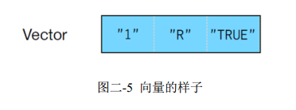

# 向量：基本操作

- 向量的创建

```r
c(1,1,1,2,3,3,1,2,4,1,2,4,4,2,3,4,1,2,3,4)
##  [1] 1 1 1 2 3 3 1 2 4 1 2 4 4 2 3 4 1 2 3 4
c("a", "b", "c", "d")
## [1] "a" "b" "c" "d"
#seq(起始值,终止值,步长)
seq(0,10,by=2)
## [1]  0  2  4  6  8 10
1:10
##  [1]  1  2  3  4  5  6  7  8  9 10
seq(1,10,length.out = 4)
## [1]  1  4  7 10
#sample(被抽取的数据集合,抽取数量)
sample(1:10,5)
## [1] 10  6  3  4  5
paste0("x_",1:5)
## [1] "x_1" "x_2" "x_3" "x_4" "x_5"
```

- 向量的引用

```r
#引用x向量中的第5个元素
x=c(1,1,1,2,3,3)
x[5]
## [1] 3
#想看看x向量中3所在的位置
which(x==3)
## [1] 5 6
which.max(x)
## [1] 5
which.min(x)
## [1] 1
```

- 集合运算

```r
intersect(c(1,2,3,3,12,4,123,12), c(1,2,3))
## [1] 1 2 3
union(c("狗熊会","聚数据英才"),c("狗熊会","助产业振兴"))
## [1] "狗熊会"     "聚数据英才" "助产业振兴"
setdiff(10:2,5:3)
## [1] 10  9  8  7  6  2
```

# 向量：常见类型

- 数值向量

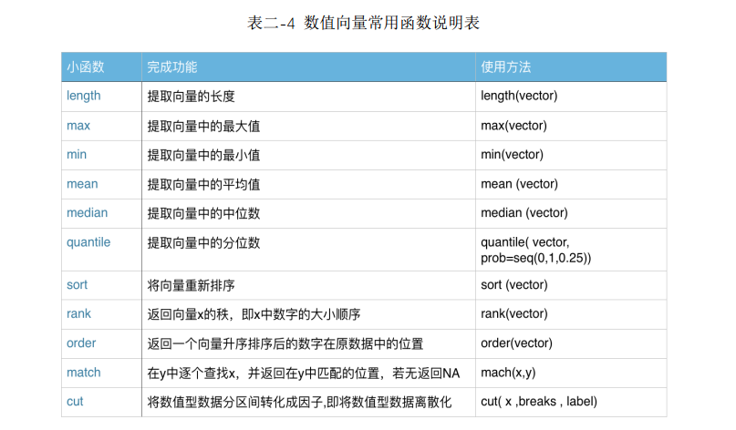

```r
#match函数
x = c(1,1,1,2,3,3,1,2,4,1,2,4,4,2,3,4,1,2,3,4)
y = letters[x];y #letters是一个内置字符串，里面储存26个字母字符
##  [1] "a" "a" "a" "b" "c" "c" "a" "b" "d" "a" "b" "d" "d" "b" "c" "d" "a" "b" "c"
## [20] "d"
match(y, letters[1:4])
##  [1] 1 1 1 2 3 3 1 2 4 1 2 4 4 2 3 4 1 2 3 4

#cut函数
Age = sample(21:100, 20, replace = T);Age
##  [1] 28 95 75 48 21 54 47 29 76 71 58 77 71 56 40 92 28 59 84 50
#将年龄数据离散化
label <- c('壮年','中年','长辈','老年')
ages <- cut(Age,breaks=c(20,30,50,70,100),labels=label);ages
##  [1] 壮年 老年 老年 中年 壮年 长辈 中年 壮年 老年 老年 长辈 老年 老年 长辈 中年
## [16] 老年 壮年 长辈 老年 中年
## Levels: 壮年 中年 长辈 老年

#sort和order函数
x=sample(8,5);x
## [1] 3 5 2 6 1
sort(x)
## [1] 1 2 3 5 6
order(x)
## [1] 5 3 1 2 4
x[order(x)]
## [1] 1 2 3 5 6
```

- 字符向量

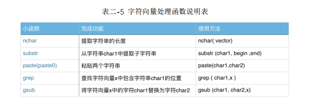

```r
#nchar用来提取字符串的长度
nchar("欢迎关注狗熊会")
## [1] 7
#看看数据集中的电影名字的长度分别是多少
nchar(movie$name)
##  [1]  3  3  7 12  5  5 12  7  8  4  5  7  4  4  6  4  4  3  2
#中英文的字符长度计算方法有不同
nchar("Welcome to follow the CluBear")
## [1] 29
#substr提取子字符串
substr("欢迎关注狗熊会",1,4)
## [1] "欢迎关注"
#paste基本玩法
paste(c("双11","是个","什么节日"),collapse = "")
## [1] "双11是个什么节日"
paste("A", 1:4)
## [1] "A 1" "A 2" "A 3" "A 4"
#paste花式玩法
paste(1:4,collapse = "")
## [1] "1234"
paste(1:4,sep="")
## [1] "1" "2" "3" "4"
paste("A", 1:4,sep="_")
## [1] "A_1" "A_2" "A_3" "A_4"
```

- 思考：你知道他们的结果吗？

```r
paste(LETTERS[1:4], 1:4,collapse = "_")
paste(LETTERS[1:4], 1:4,sep = "_",collapse = "|")
paste(LETTERS[1:4], 1:4)
```

- 查找替换函数

```r
txt = c("狗熊会", "CluBear", "双11", "生日")
#返回含有关键字的字符位置
grep("Bear", txt)
## [1] 2
gsub("生日", "happy birthday", txt)
## [1] "狗熊会"         "CluBear"        "双11"           "happy birthday"

#grep返回movie的name中包含"青春"的行号8,movie[8,]即提取出movie数据集的第8行
index=grep("青春",movie$name);index
## [1] 8
young=movie[index,];young
##             name boxoffice doubanscore type duration   showtime director  star1
## 8 谁的青春不迷茫  17798.89         6.4 爱情      108 2016-04-22   姚婷婷 白敬亭
##   index1  star2 index2
## 8  14759 郭姝彤    755
#看看它的豆瓣评分和票房处于我们电影数据集中的什么位置
young$doubanscore>mean(movie$doubanscore)
## [1] TRUE
young$boxoffice>mean(movie$boxoffice)
## [1] FALSE
```

- 思考题：有以下5个人的工资，试计算他们的均值并给出如下输出

```
## [1] "22万"  "30万"  "50万"  "120万" "11万"
## [1] 466000
```